# Part 1: R Reference Guide

E. Baylor

12/16/2021

# R Reference Guide

## Loading Data and Packages

```r
require(here)
library(palmerpenguins)

ginkgo <- data.frame(
  read.csv(here("data", "ginkgo_data_2021.csv"))
)
```

## Data Structures

### C()

The function c() combines or concatenates its arguments into a vector (a 1-dimensional data structure consisting of 1 or more elements).

All of the elements must be of the same type. I can’t combine character and numeric types in the same call to c() Here’s two examples using numeric and character data types:

```r
## Create a vector of numbers:
num_vec  = c(1, 4, 8, 9, 13)

##Create a vector of characters:
char_vec = c("a", "fish", "data is cool")
```

I can show the contents of a vector by typing the name of the vector, or using the print() function.

```r
## Typing the name of the vector into the console prints the contents
num_vec
```

```
## [1]  1  4  8  9 13
```

```r
## The print() function accomplishes the same task:
print(char_vec)
```

```
## [1] "a"            "fish"         "data is cool"
```

### Length ()

The function length() is used to determine the ength of a vector of factor.

```r
length(ginkgo$petiole_length)
```

```
## [1] 756
```

### Matrix()

The function Matrix() creates the Matrix from data values.

```r
matrix(data = 0:70, nrow = 7, ncol = 7, byrow = FALSE)
```

```
##      [,1] [,2] [,3] [,4] [,5] [,6] [,7]
## [1,]    0    7   14   21   28   35   42
## [2,]    1    8   15   22   29   36   43
## [3,]    2    9   16   23   30   37   44
## [4,]    3   10   17   24   31   38   45
## [5,]    4   11   18   25   32   39   46
## [6,]    5   12   19   26   33   40   47
## [7,]    6   13   20   27   34   41   48
```

### Data.frame()

The function data.frame() is a list of two or more related variables.

```r
head(data.frame(ginkgo))
```

```
##   site_id seeds_present max_width max_depth notch_depth petiole_length
## 1    7719         FALSE        71        40           0             30
## 2    7719         FALSE        64        38           0             23
## 3    7719         FALSE        55        32           0             20
## 4    7719         FALSE        62        40           0             28
## 5    7719         FALSE        65        40           0             25
## 6    7719         FALSE        70        50           0             55
```

```r
nrow(ginkgo)
```

```
## [1] 756
```

```r
ncol(ginkgo)
```

```
## [1] 6
```

```r
dim(ginkgo)
```

```
## [1] 756   6
```

## Subsetting

### $

```r
head(ginkgo$petiole_length)
```

```
## [1] 30 23 20 28 25 55
```

### []

```r
ginkgo[1,]
```

```
##   site_id seeds_present max_width max_depth notch_depth petiole_length
## 1    7719         FALSE        71        40           0             30
```

```r
ginkgo[2,3]
```

```
## [1] 64
```

```r
head(ginkgo[,3])
```

```
## [1] 71 64 55 62 65 70
```

### Subset()

```r
head(subset(penguins, species == "Adelie"))
```

```
##   species    island bill_length_mm bill_depth_mm flipper_length_mm body_mass_g
## 1  Adelie Torgersen           39.1          18.7               181        3750
## 2  Adelie Torgersen           39.5          17.4               186        3800
## 3  Adelie Torgersen           40.3          18.0               195        3250
## 4  Adelie Torgersen             NA            NA                NA          NA
## 5  Adelie Torgersen           36.7          19.3               193        3450
## 6  Adelie Torgersen           39.3          20.6               190        3650
##      sex year
## 1   male 2007
## 2 female 2007
## 3 female 2007
## 4   <NA> 2007
## 5 female 2007
## 6   male 2007
```

## Numerical Data Exploration

### Summary()

The function Summary() is used to get the summary of various model fitting functions.

```r
summary(ginkgo)
```

```
##     site_id      seeds_present     max_width        max_depth
##  Min.   : 1896   Mode :logical   Min.   : 16.00   Min.   : 19.00
##  1st Qu.: 3703   FALSE:636       1st Qu.: 63.00   1st Qu.: 43.00
##  Median : 6066   TRUE :120       Median : 74.00   Median : 51.00
##  Mean   : 6079                   Mean   : 74.34   Mean   : 58.51
##  3rd Qu.: 7206                   3rd Qu.: 85.00   3rd Qu.: 66.00
##  Max.   :12982                   Max.   :130.00   Max.   :145.00
##
##   notch_depth    petiole_length
##  Min.   : 0.00   Min.   :  8.00
##  1st Qu.: 0.00   1st Qu.: 34.00
##  Median : 0.00   Median : 47.00
##  Mean   : 2.99   Mean   : 48.25
##  3rd Qu.: 4.00   3rd Qu.: 60.00
##  Max.   :49.00   Max.   :113.00
##                  NA's   :4
```

### Mean()

The function mean() is used to calculate the average of a list.

```r
mean(ginkgo$notch_depth)
```

```
## [1] 2.990079
```

### sd()

The function sd() is used to determine the standard deviation of any given values in x.

```r
sd(ginkgo$notch_depth)
```

```
## [1] 5.982555
```

## Graphical Data Exploration

### Scatterplot()

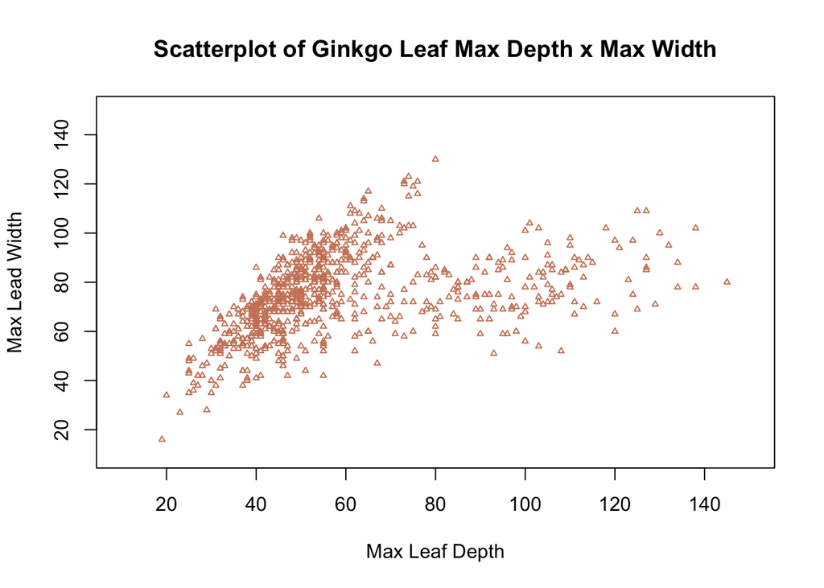

```r
plot(max_width ~ max_depth, data = ginkgo,
     xlab = "Max Leaf Depth", ylab = "Max Lead Width",
     main = "Scatterplot of Ginkgo Leaf Max Depth x Max Width",
     col = "#CD8162", xlim = c(10, 150), ylim = c(10, 150), pch= 2, cex = .5)
```

### Histogram()

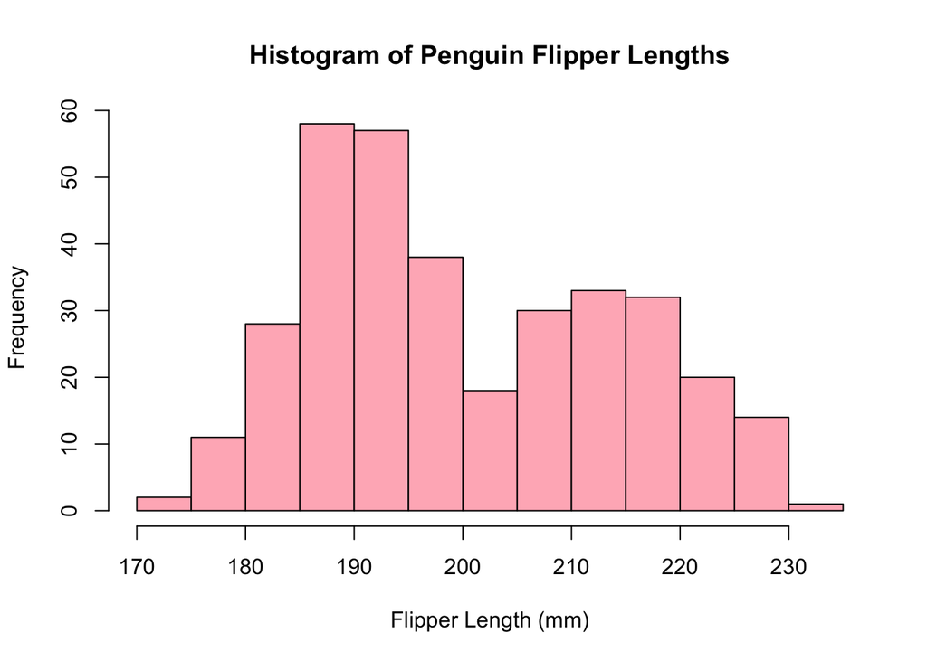

```r
require(palmerpenguins)
penguins <- data.frame(penguins)

hist(penguins$flipper_length_mm, breaks = 10, main = "Histogram of Penguin Flipper Lengths", xlab = "Flipper Length (mm)", col = "lightpink")
```

### Boxplot()

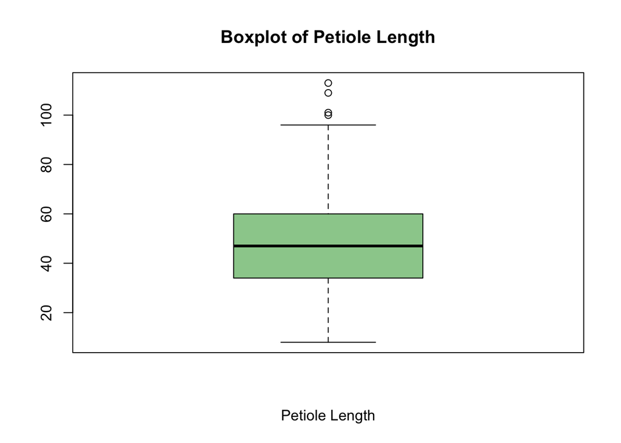

```r
boxplot(ginkgo$petiole_length, xlab = "Petiole Length", main = "Boxplot of Petiole Length", col = "#9BCD9B")
```

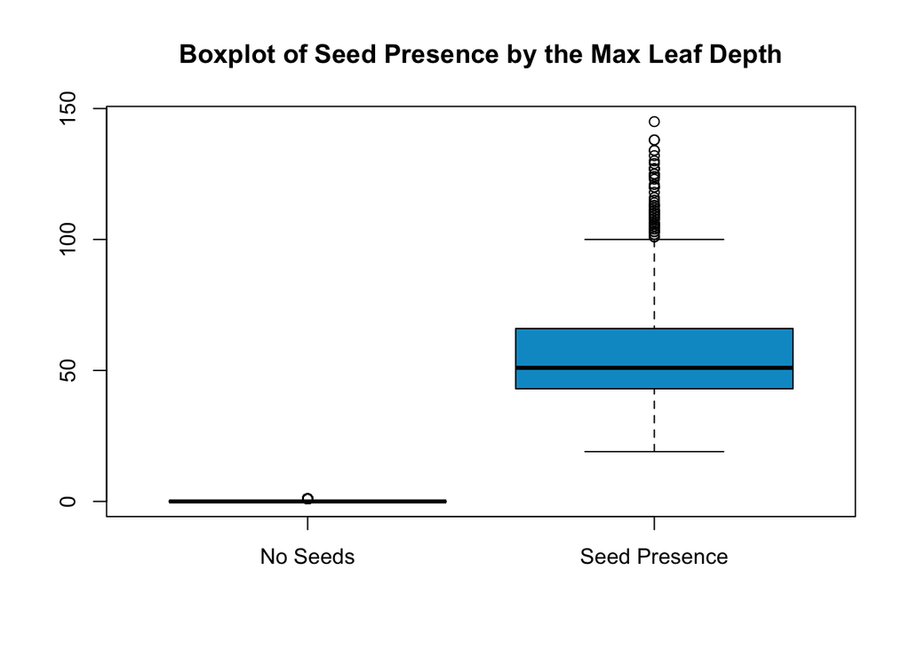

```r
boxplot(ginkgo$seeds_present, ginkgo$max_depth, names = c("No Seeds", "Seed Presence"), main = "Boxplot of Seed Presence by the Max Leaf Depth", col = "#009ACD")
```

### Par() and Mrow of Histograms

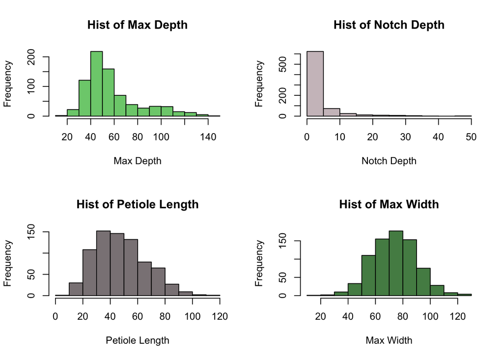

```r
par(mfrow = c(2, 2))
hist(ginkgo$max_depth, main = "Hist of Max Depth", xlab = "Max Depth", col = "#7CCD7C")

hist(ginkgo$notch_depth, main = "Hist of Notch Depth", xlab = "Notch Depth", col = "#CDC1C5")

hist(ginkgo$petiole_length, main = "Hist of Petiole Length", xlab = "Petiole Length", col = "#8B8386")

hist(ginkgo$max_width, main = "Hist of Max Width", xlab = "Max Width", col = "#548B54")
```

## Distribution Functions

### Dnorm()

The function dnorm() calculates the density of normal distribution.

```r
dnorm(x = -7:7, mean = 1, sd = 3)
```

```
##  [1] 0.003798662 0.008740630 0.017996989 0.033159046 0.054670025 0.080656908
##  [7] 0.106482669 0.125794409 0.132980760 0.125794409 0.106482669 0.080656908
## [13] 0.054670025 0.033159046 0.017996989
```

### Pnorm()

The function pnorm() calculates the distribution function of normal distribution.

```r
pnorm(0, mean = 0, sd = 3)
```

```
## [1] 0.5
```

### Qnorm()

The function qnorm() calculates the quantile function of normal distribution.

```r
qnorm(0.10, mean = 0, sd = 3)
```

```
## [1] -3.844655
```

### Dbinom()

The function dbinom() calculates the density of binomial distribution.

```r
dbinom(x = 1:10, size = 10, prob = 0.3)
```

```
##  [1] 0.1210608210 0.2334744405 0.2668279320 0.2001209490 0.1029193452
##  [6] 0.0367569090 0.0090016920 0.0014467005 0.0001377810 0.0000059049
```

### Pbinom()

The function pbinom() calculates the distribution function of binomial distribution.

```r
pbinom(100, size = 10, prob = 0.3)
```

```
## [1] 1
```

### Qbinom()

The function qbinom() calculates the quantile function of binomial distribution.

```r
qbinom(p = 0.77, size = 5, prob = 0.33)
```

```
## [1] 2
```